# Testthat - 3rd edition

03 February 2022

## Outline

- Package development workflow
- 3 levels of R package testing
- Why unit test?
- Packages for unit testing in R
- `testthat` overview
- What’s new in `testthat` 3rd edition?

## Package development workflow

[figure not shown]

## 3 levels of R package testing

- **Unit testing** for individual functions
- **R CMD Check**/**BiocCheck** for overall package structure and formating
- **GitHub actions** to test on multiple OS

## Why unit test?

- You already do this manually
  1. Create a function
  2. Assess output on console
  3. Repeat
- Unit testing **automates** this process
- Future updates won’t break existing code
- Guides you to follow **functional programming** principles

## Packages for unit testing in R

- `testthat` - https://cran.r-project.org/web/packages/RUnit/vignettes/RUnit.pdf)
- `RUnit` - https://cran.r-project.org/web/packages/RUnit/vignettes/RUnit.pdf)

## `testthat` overview

- Used in **~5000** packages in CRAN
- Easy functions included in `usethis` to generate unit tests:
  - `usethis::use_testthat` - creates test directory, adds `testthat` to Suggests
  - `usethis::use_test("function_name")`
- If you catch a bug, write a test

## `testthat` example

- You have an expectation - `expect_*`
- That **must** match your `object`

```r
x <- 1:3
y <- c(1:3, NA)

testthat::test_that("test mean", {
  testthat::expect_equal(object = mean(x), expected = 2)
  testthat::expect_true(object = is.na(mean(y)))
  testthat::expect_warning(object = mean(c("1", "2")))
})
```

```
## Test passed 🎉
```

## `testthat` example

```r
get_sum_stats <- function(df, sum_vars, group_vars = NULL,
                          sum_funcs = list(mean = mean, sd = sd)){

    if (!is.null(group_vars)) {
        df <- df %>%
            dplyr::group_by_at(.vars = group_vars)
    }

    df_summary <- df %>%
        dplyr::summarise_at(
            .vars = sum_vars,
            .funs = sum_funcs
        )

    return(df_summary)

}
```

## `testthat` example

```r
df <- dplyr::tibble(var1 = rep(c("a", "b", "c"), 4),
                    var2 = rep(c("some", "example", "groups"), 4),
                    x = c(1:6, 6:1),
                    y = 1:12)

df
```

```
## # A tibble: 12 × 4
##    var1  var2        x     y
##    <chr> <chr>   <int> <int>
##  1 a     some        1     1
##  2 b     example     2     2
##  3 c     groups      3     3
##  4 a     some        4     4
##  5 b     example     5     5
##  6 c     groups      6     6
##  7 a     some        6     7
##  8 b     example     5     8
##  9 c     groups      4     9
## 10 a     some        3    10
## 11 b     example     2    11
## 12 c     groups      1    12
```

## `testthat` example

```r
get_sum_stats(df, sum_vars = "y", group_vars = c("var1", "var2"))
```

```
## # A tibble: 3 × 4
## # Groups:   var1 [3]
##   var1  var2     mean    sd
##   <chr> <chr>   <dbl> <dbl>
## 1 a     some      5.5  3.87
## 2 b     example   6.5  3.87
## 3 c     groups    7.5  3.87
```

## `testthat` example

```r
df_summary <- get_sum_stats(df, sum_vars = "y",
                            group_vars = c("var1", "var2"))

testthat::test_that("get_sum_stats has correct output", {

    testthat::expect_equivalent(
        df_summary,
        df %>%
            dplyr::group_by(var1, var2) %>%
            dplyr::summarise_at("y", list(mean, sd))
    )
})
```

```
## Test passed 🥇
```

## `testthat` example

```r
df_summary %>%
    dplyr::filter(!duplicated(sd))
```

```
## # A tibble: 3 × 4
## # Groups:   var1 [3]
##   var1  var2     mean    sd
##   <chr> <chr>   <dbl> <dbl>
## 1 a     some      5.5  3.87
## 2 b     example   6.5  3.87
## 3 c     groups    7.5  3.87
```

## `testthat` example

```r
df_summary %>%
    dplyr::ungroup() %>%
    dplyr::filter(!duplicated(sd))
```

```
## # A tibble: 1 × 4
##   var1  var2   mean    sd
##   <chr> <chr> <dbl> <dbl>
## 1 a     some    5.5  3.87
```

## `testthat` example

```r
get_sum_stats <- function(df, sum_vars, group_vars = NULL,
                      sum_funcs = list(mean = mean, sd = sd)){

    if (!is.null(group_vars)) {
        df <- df %>%
            dplyr::group_by_at(.vars = group_vars)
    }

    df_summary <- df %>%
        dplyr::summarise_at(
            .vars = sum_vars,
            .funs = sum_funcs
        ) %>%
        ungroup()

    return(df_summary)

}
```

## `testthat` example

```r
df_summary <- get_sum_stats(df, sum_vars = "y",
                            group_vars = c("var1", "var2"))

testthat::test_that("get_sum_stats has correct output", {

    testthat::expect_equal(
        df_summary %>%
            dplyr::filter(!duplicated(sd)) %>%
            nrow(),
        1
    )
})
```

```
## Test passed 🥇
```

## What’s new in `testthat` 3rd edition?

- The idea of **editions**
- Deprecation of various old features
- **waldo** comparison of differences
- **Snapshot** tests
- Parallel testing

## Editions

- Optional opt in for new features
- Enable backwards compatibility
- Default for new packages
- for old you have to include in in your `DESCRIPTION`:

```r
Config/testthat/edition: 3
```

## Deprecations

- `context`
- `expect_is` -> `expect_s3_class`/`expect_s4_class`
- `expect_equivalent` -> `expect_equal`/`expect_identical`

## Waldo comparisons example

```r
testthat::local_edition(2)
```

```
## Setting deferred event(s) on global environment.
##   * Will be run automatically when session ends
##   * Execute (and clear) with `withr::deferred_run()`.
##   * Clear (without executing) with `withr::deferred_clear()`.
```

```r
testthat::expect_equal(as.character(1:10), as.factor(1:10))
```

```
## Error: as.character(1:10) not equal to as.factor(1:10).
## Types not compatible: character is not integer
```

## Waldo comparisons example

```r
testthat::local_edition(3)

testthat::expect_equal(as.character(1:10), as.factor(1:10))
```

```
## Error: as.character(1:10) (`actual`) not equal to as.factor(1:10) (`expected`).
##
## `actual` is a character vector ('1', '2', '3', '4', '5', ...)
## `expected` is an S3 object of class <factor>, an integer vector
```

## Waldo comparisons example

```r
testthat::local_edition(2)

testthat::expect_equal(iris[-1], iris)
```

```
## Error: iris[-1] not equal to `iris`.
## Names: 4 string mismatches
## Length mismatch: comparison on first 4 components
## Component 1: Mean relative difference: 0.9112516
## Component 2: Mean relative difference: 0.5352138
## Component 3: Mean relative difference: 2.133407
## Component 4: 'current' is not a factor
```

## Waldo comparisons example

```r
testthat::local_edition(3)

testthat::expect_equal(iris[-1], iris)
```

```
## Error: iris[-1] (`actual`) not equal to `iris` (`expected`).
##
## `actual` is length 4
## `expected` is length 5
##
## `names(actual)[1:3]`:                  "Sepal.Width" "Petal.Length" "Petal.Width"
## `names(expected)[1:4]`: "Sepal.Length" "Sepal.Width" "Petal.Length" "Petal.Width"
##
## `actual$Sepal.Length` is absent
## `expected$Sepal.Length` is a double vector (5.1, 4.9, 4.7, 4.6, 5, ...)
```

## Snapshot tests

- For expectations that are difficult to describe in code or text
- `.html` output
- `ggplot`s
- Snapshot tests save the actual output upon first run, then compares expectation to this in subsequent runs.
- Supersedes `verify_output()`

## Snapshot tests example

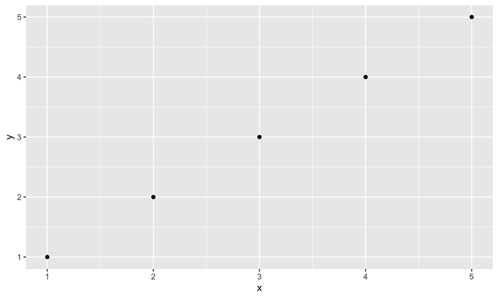

```r
snapshot_plot <- tibble::tibble(x = 1:5, y = 1:5) %>%
    ggplot2::ggplot(aes(x, y)) +
    ggplot2::geom_point()

snapshot_plot
```

```r
testthat::local_edition(3)

testthat::test_that("snapshot plot is correct", {

    testthat::expect_true(is(snapshot_plot, "ggplot"))

})
```

```
## Test passed 🌈
```

## Snapshot tests example

- The remaining examples require the structure of package so will shown interactively
- Snapshot workflow:

```r
usethis::create_package("~/testsnapshot")
usethis::use_testthat()
usethis::use_test("test_snapshot")
```

## Parallel testing

- Add to `DESCRIPTION`:

```r
Config/testthat/parrallel: true
```

- Speeds up tests, but does have an overhead
- Run in random order, can’t have dependencies between tests

## Resources

- R packages testing page - https://r-pkgs.org/tests.html
- `testthat` vignette - https://testthat.r-lib.org/
- Webinar on new functionality in `testthat` edition 3 - https://rstudio.com/resources/webinars/testthat-3/